# RNA-seq Analysis in R

Annotation and Visualisation of Differential Expression Results

Stephane Ballereau, Dominique-Laurent Couturier, Mark Dunning, Abbi Edwards, Ashley Sawle

Last modified: 20 Jul 2020

```r
library(EnsDb.Mmusculus.v79)
library(DESeq2)
library(tidyverse)
```

Before starting this section, we will make sure we have all the relevant objects from the Differential Expression analysis.

```r
load("Robjects/DE.RData")
```

# Overview

- Getting annotation
- Visualising DE results

# Adding annotation to the DESeq2 results

We have a list of significantly differentially expressed genes, but the only annotation we can see is the Ensembl Gene ID, which is not very informative.

There are a number of ways to add annotation. One method is to do this using a Bioconductor annotation package. These packages which are re-built every periodically with the latest annotations. These packages are listed on the [annotation section](http://bioconductor.org/packages/release/BiocViews.html#___AnnotationData) of the Bioconductor, and are installed in the same way as regular Bioconductor packages.

An alternative approach is to use `biomaRt`, an interface to the [BioMart](http://www.biomart.org/) resource. Using BioMart ensures that you are able to get the latest annotations for the GeneIDs, and can match the version of the gene annotation that was used for read counting.

Using an annotation packages means that you may not have the exact same version of the gene annotations as was used to do the counting.

Today we will use the annotation package method.

## Query the database

We use the select function to query the database. Now we need to set up a query. This requires us to tell it what we want and what we have. For this we need to specify three things:

1. What type of information we are going to search the dataset on - called **keytypes**. In our case this is Ensembl Gene IDs
2. A vector of the **keys** for our filter - the Ensembl Gene IDs from our DE results table
3. What columns (**columns**) of the dataset we want returned.

```r
# what can we search for? 'columns'
columns(EnsDb.Mmusculus.v79)
```

```
##  [1] "ENTREZID"            "EXONID"              "EXONIDX"
##  [4] "EXONSEQEND"          "EXONSEQSTART"        "GENEBIOTYPE"
##  [7] "GENEID"              "GENENAME"            "GENESEQEND"
## [10] "GENESEQSTART"        "INTERPROACCESSION"   "ISCIRCULAR"
## [13] "PROTDOMEND"          "PROTDOMSTART"        "PROTEINDOMAINID"
## [16] "PROTEINDOMAINSOURCE" "PROTEINID"           "PROTEINSEQUENCE"
## [19] "SEQCOORDSYSTEM"      "SEQLENGTH"           "SEQNAME"
## [22] "SEQSTRAND"           "SYMBOL"              "TXBIOTYPE"
## [25] "TXCDSSEQEND"         "TXCDSSEQSTART"       "TXID"
## [28] "TXNAME"              "TXSEQEND"            "TXSEQSTART"
## [31] "UNIPROTDB"           "UNIPROTID"           "UNIPROTMAPPINGTYPE"
```

```r
# what can we search with? 'keytypes'
keytypes(EnsDb.Mmusculus.v79)
```

```
##  [1] "ENTREZID"            "EXONID"              "GENEBIOTYPE"
##  [4] "GENEID"              "GENENAME"            "PROTDOMID"
##  [7] "PROTEINDOMAINID"     "PROTEINDOMAINSOURCE" "PROTEINID"
## [10] "SEQNAME"             "SEQSTRAND"           "SYMBOL"
## [13] "TXBIOTYPE"           "TXID"                "TXNAME"
## [16] "UNIPROTID"
```

```r
# lets set it up
ourCols <- c("SYMBOL", "GENEID", "ENTREZID")
ourKeys <- rownames(resLvV)[1:1000]

# run the query
annot <- AnnotationDbi::select(EnsDb.Mmusculus.v79,
                keys=ourKeys,
                columns=ourCols,
                keytype="GENEID")
```

### One-to-many relationships

Let's inspect the annotation.

```r
head(annot)
```

```
##         SYMBOL             GENEID ENTREZID
## 1         Xkr4 ENSMUSG00000051951   497097
## 2 RP23-122M2.3 ENSMUSG00000102331       NA
## 3          Rp1 ENSMUSG00000025900    19888
## 4        Sox17 ENSMUSG00000025902    20671
## 5       Gm6085 ENSMUSG00000098104       NA
## 6 RP23-34E15.4 ENSMUSG00000103922       NA
```

```r
length(unique(annot$ENTREZID)) # Why are there NAs in the ENTREZID column?
```

```
## [1] 533
```

```r
dim(annot) # why are there more than 1000 rows?
```

```
## [1] 1010    3
```

```r
# find all rows containing duplicated ensembl ids
annot %>%
    add_count(GENEID) %>%
    dplyr::filter(n>1)
```

```
##           SYMBOL             GENEID  ENTREZID n
## 1          Tceb1 ENSMUSG00000079658     67923 2
## 2          Tceb1 ENSMUSG00000079658 102642819 2
## 3         Ptp4a1 ENSMUSG00000026064     19243 2
## 4         Ptp4a1 ENSMUSG00000026064 102643131 2
## 5          Cox5b ENSMUSG00000061518     12859 3
## 6          Cox5b ENSMUSG00000061518 102638382 3
## 7          Cox5b ENSMUSG00000061518 102641600 3
## 8          Rpl31 ENSMUSG00000073702    665562 2
## 9          Rpl31 ENSMUSG00000073702 102641215 2
## 10         Hspd1 ENSMUSG00000025980     15510 2
## 11         Hspd1 ENSMUSG00000025980 102641967 2
## 12           Mff ENSMUSG00000026150     75734 2
## 13           Mff ENSMUSG00000026150 102643056 2
## 14 C130026I21Rik ENSMUSG00000052477    381287 4
```

[output cut: 16 more lines]

There are quite a few Ensembl IDs with no EntrezID. This either due to differences in versions between our gtf we used for counting and the version in the *EnsDb.Mmusculus.v79* or they haven't designated a match for that ID. The two databases don't match on a 1:1 level although they are taking step towards consolidating in recent years.

There are some genes that have multiple entries in the retrieved annotation. This is becaues there are multiple Entrez IDs for a single Ensembl gene. These one-to-many relationships come up frequently in genomic databases, it is important to be aware of them and check when necessary.

We will need to do a little work before adding the annotation to out results table. We could decide to discard one or both of the Entrez ID mappings, or we could concatenate the Entrez IDs so that we don't lose information.

## Exercise 1 - Retrieve the full annotation

> So far we have retrieved the annotation for just 1000 genes, but we need annotations for the entire results table.

> A reminder of the code we have used so far:

```r
# lets set it up
ourCols <- c("GENEID", "SYMBOL", "ENTREZID")
ourKeys <- rownames(resLvV)[1:1000]

# run the query
annot <- AnnotationDbi::select(EnsDb.Mmusculus.v79,
                keys=ourKeys,
                columns=ourCols,
                keytype="GENEID")
```

> 1. Run the same query using all of the genes in our results table (`resLvV`), and this time include the biotype of the genes too. Hint: You can find the name of the column for this by running `columns(EnsDb.Mmusculus.v79)`
> 2. How many Ensembl genes have multipe Entrez IDs associated with them?
> 3. Are all of the Ensembl gene IDs annotated? If not, why do you think this is?

## A curated annotation - one we prepared earlier

Dealing with all the one-to-many annotation mappings requires some manual curation of your annotation table.

To save time we have created an annotation table in which we have modified the column names and dealt with the one-to-many/missing issues for Entrez IDs.

```r
load("Robjects/Ensembl_annotations.RData")
colnames(ensemblAnnot)
```

```
##  [1] "GeneID"         "Entrez"         "Symbol"         "Description"
##  [5] "Biotype"        "Chr"            "Start"          "End"
##  [9] "Strand"         "medianTxLength"
```

```r
annotLvV <- as.data.frame(resLvV) %>%
    rownames_to_column("GeneID") %>%
    left_join(ensemblAnnot, "GeneID") %>%
    rename(logFC=log2FoldChange, FDR=padj)
```

Finally we can output the annotation DE results using `write_tsv`.

```r
write_tsv(annotLvV, "results/VirginVsLactating_Results_Annotated.txt")
```

# Visualisation

## P-value histogram

A quick and easy "sanity check" for our DE results is to generate a p-value histogram. What we should see is a high bar at `0 - 0.05` and then a roughly uniform tail to the right of this. There is a nice explanation of other possible patterns in the histogram and what to do when you see them in [this post](http://varianceexplained.org/statistics/interpreting-pvalue-histogram/).

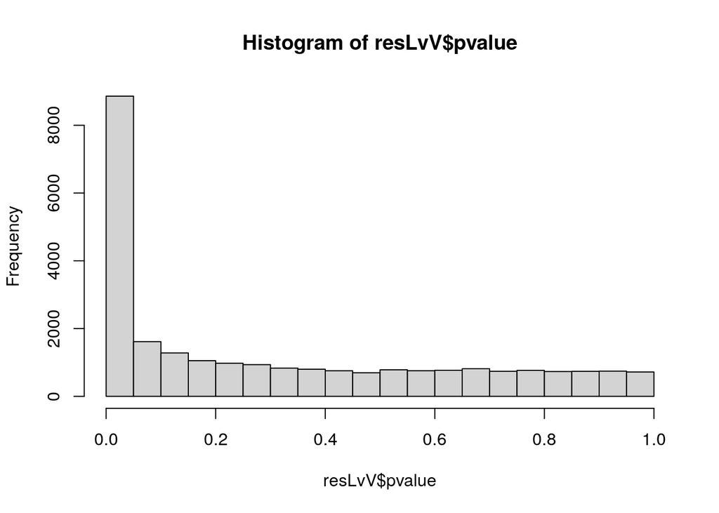

```r
hist(resLvV$pvalue)
```

## Shrinking the log2FoldChange

`DESeq2` provides a functon called `lfcShrink` that shrinks log-Fold Change (LFC) estimates towards zero using and empirical Bayes procedure. The reason for doing this is that there is high variance in the LFC estimates when counts are low and this results in lowly expressed genes appearing to show greater differences between groups than highly expressed genes. The `lfcShrink` method compensates for this and allows better visualisation and ranking of genes. We will use it for our visualisation of the data.

```r
ddsShrink <- lfcShrink(ddsObj, coef="Status_lactate_vs_virgin")
```

```
## using 'apeglm' for LFC shrinkage. If used in published research, please cite:
##     Zhu, A., Ibrahim, J.G., Love, M.I. (2018) Heavy-tailed prior distributions for
##     sequence count data: removing the noise and preserving large differences.
##     Bioinformatics. https://doi.org/10.1093/bioinformatics/bty895
```

```r
shrinkLvV <- as.data.frame(ddsShrink) %>%
    rownames_to_column("GeneID") %>%
    left_join(ensemblAnnot, "GeneID") %>%
    rename(logFC=log2FoldChange, FDR=padj)
```

## MA plots

MA plots are a common way to visualize the results of a differential analysis. We met them briefly towards the end of Session 2. This plot shows the log-Fold Change for each gene against its average expression across all samples in the two conditions being contrasted.  
`DESeq2` has a handy function for plotting this. Let's use it too compare the shrunk and un-shrunk fold changes.

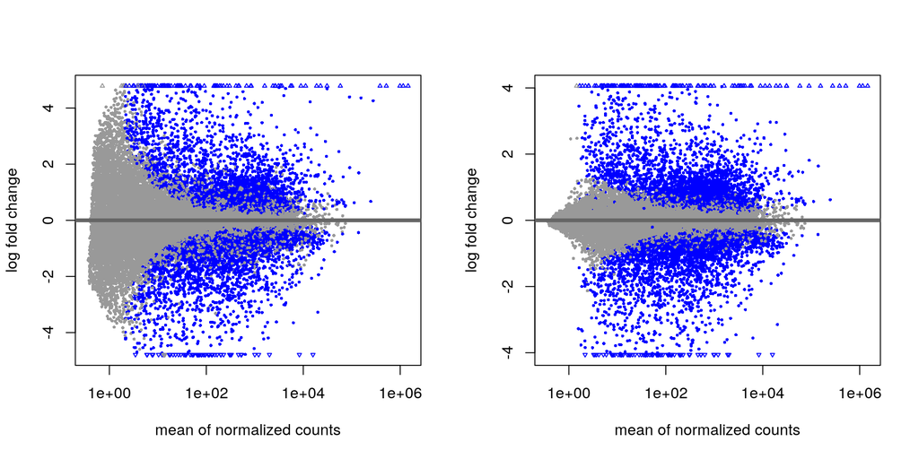

```r
par(mfrow=c(1,2))
plotMA(resLvV, alpha=0.05)
plotMA(ddsShrink, alpha=0.05)
```

### A Brief Introduction to `ggplot2`

The [`ggplot2`](http://ggplot2.tidyverse.org/) package has emerged as an attractive alternative to the traditional plots provided by base R. A full overview of all capabilities of the package is available from the [cheatsheet](https://www.rstudio.com/wp-content/uploads/2015/03/ggplot2-cheatsheet.pdf).

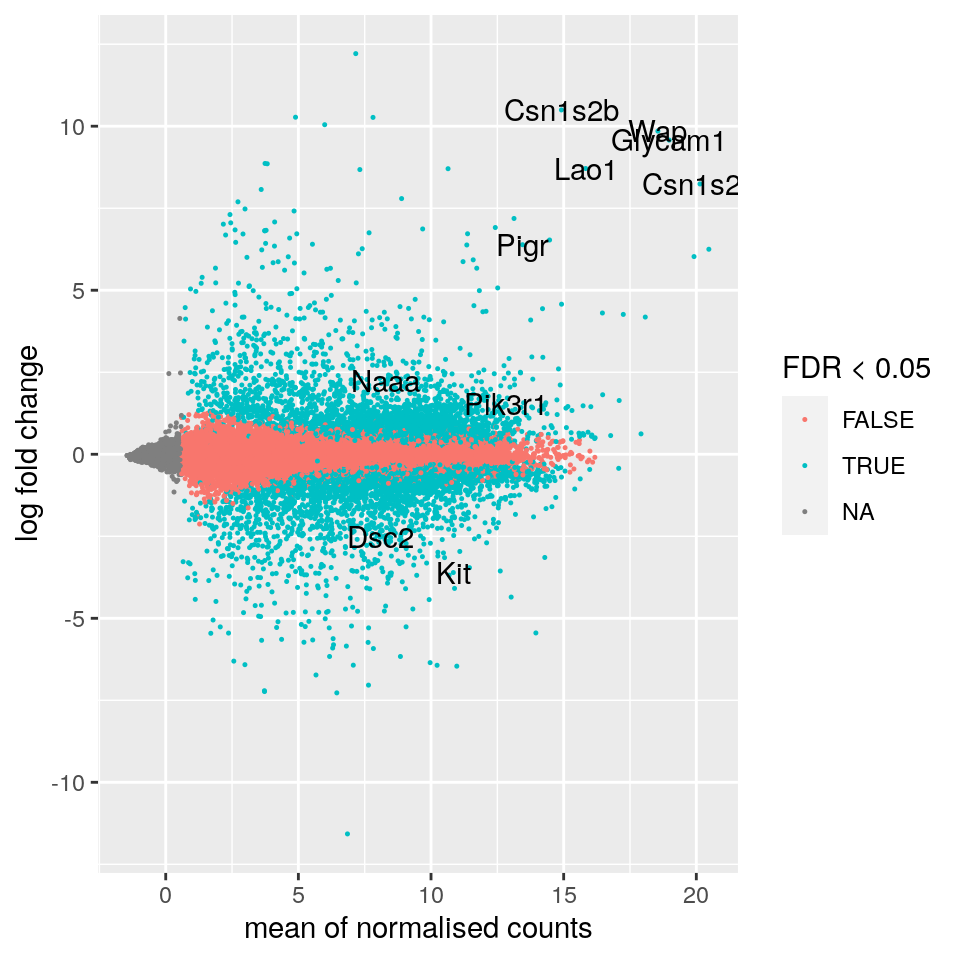

```r
ggplot(shrinkLvV, aes(x = log2(baseMean), y=logFC)) +
    geom_point(aes(colour=FDR < 0.05), shape=20, size=0.5) +
    geom_text(data=~top_n(.x, 10, wt=-FDR), aes(label=Symbol)) +
    labs(x="mean of normalised counts", y="log fold change")
```

## Challenge 2 - Volcano plot

Another common visualisation is the *volcano plot* which displays a measure of significance on the y-axis and fold-change on the x-axis.

If you haven't already make sure you load in our data and annotation. Then shrink the values. You can copy and paste the code below.

```r
# First load data and annotations
load("../Robjects/DE.RData")
load("../Robjects/Ensembl_annotations.RData")

#Shrink our values
ddsShrink <- lfcShrink(ddsObj, coef="Status_lactate_vs_virgin")
shrinkLvV <- as.data.frame(ddsShrink) %>%
    rownames_to_column("GeneID") %>%
    left_join(ensemblAnnot, "GeneID") %>%
    rename(logFC=log2FoldChange, FDR=padj)
```

> Use the log2 fold change (`logFC`) on the x-axis, and use `-log10(pvalue)` on the y-axis. (This `-log10` transformation is commonly used for p-values as it means that more significant genes have a higher scale)
> 1. Create a new column of -log10(pvalue) values in shrinkLvV
> 2. Create a plot with points coloured by FDR < 0.05 similar to how we did in the MA plot

An example of what your plot should look like:

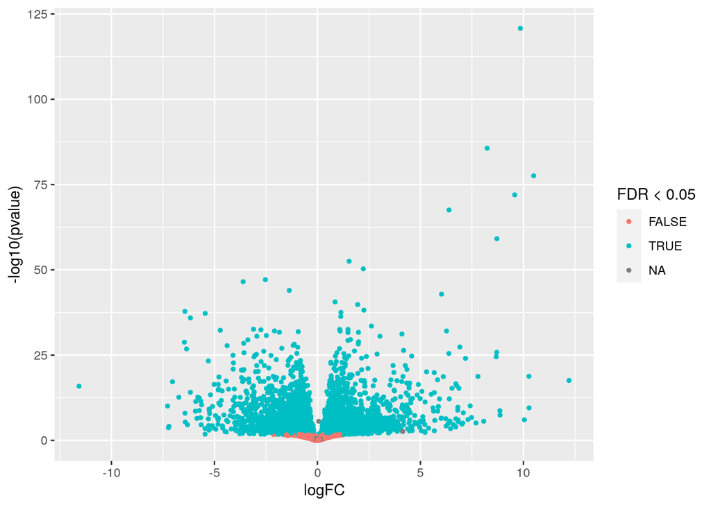

## Heatmap

We're going to use the package `ComplexHeatmap` (Z. Gu, Eils, and Schlesner 2016). We'll also use `circlize` to generate a colour scale (Z. Gu et al. 2014).

```r
library(ComplexHeatmap)
library(circlize)
```

We can't plot the entire data set, let's just select the top 150 by FDR. We'll want to use normalised expression values, so we'll use the `vst` function.

```r
# get the top genes
sigGenes <- shrinkLvV %>%
    top_n(150, wt=-FDR) %>%
    pull("GeneID")

# filter the data for the top 200 by padj in the LRT test
plotDat <- vst(ddsObj)[sigGenes,] %>%
    assay()
```

The range expression values for different genes can vary widely. Some genes will have very high expression. Our heatmap is going to be coloured according to gene expression. If we used a colour scale from 0 (no expression) to the maximum expression, the scale will be dominated by our most extreme genes and it will be difficult to discern any difference between most of the genes.

To overcome this we will z-scale the counts. This scaling method results in values for each that show the number of standard deviations the gene expression is from the mean for that gene across all the sample - the mean will be '0', '1' means 1 standard deviation higher than the mean, '-1' means 1 standard deviation lower than the mean.

```r
z.mat <- t(scale(t(plotDat), center=TRUE, scale=TRUE))
```

```r
# colour palette
myPalette <- c("royalblue3", "ivory", "orangered3")
myRamp <- colorRamp2(c(-2, 0, 2), myPalette)
```

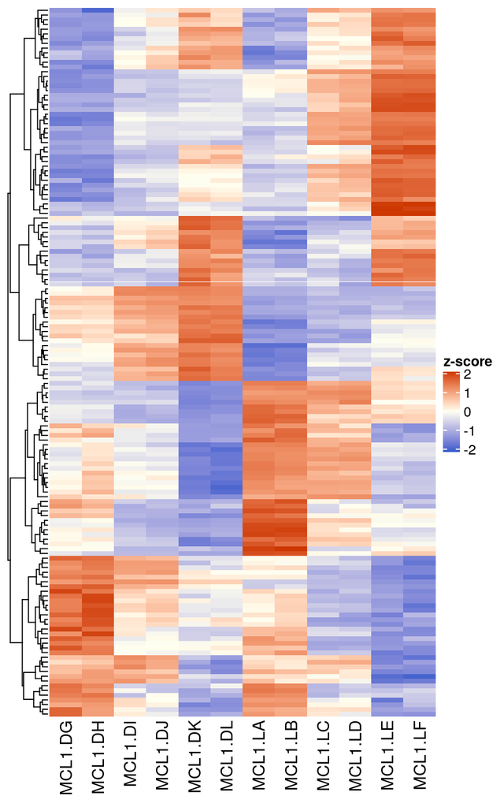

```r
Heatmap(z.mat, name = "z-score",
        col = myRamp,
        show_row_names = FALSE,
        cluster_columns = FALSE)
```

we can also split the heat map into clusters and add some annotation.

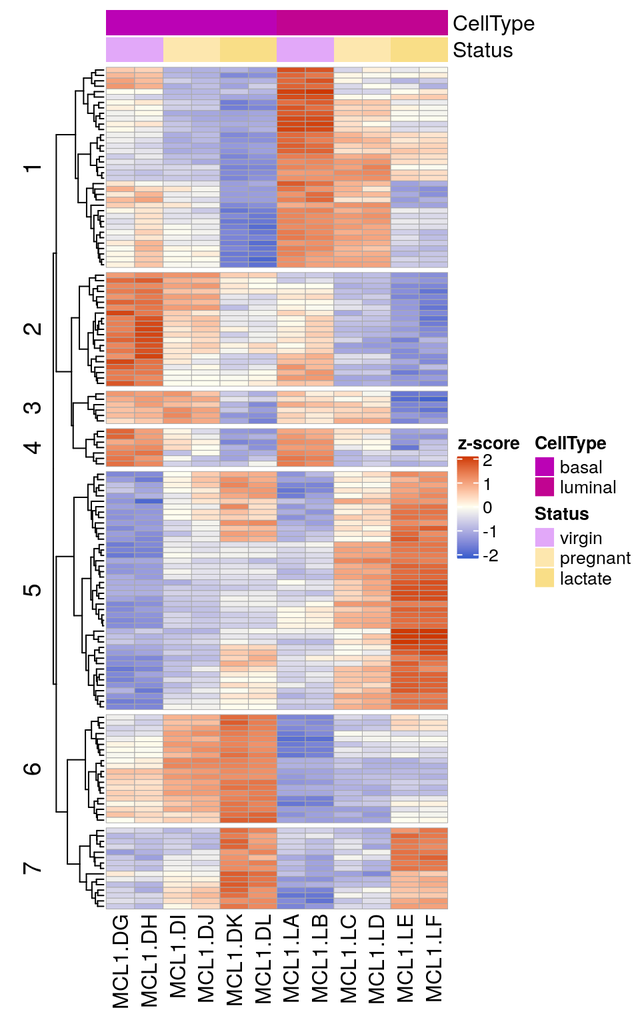

```r
ha1 = HeatmapAnnotation(df = colData(ddsObj)[,c("CellType", "Status")])

Heatmap(z.mat, name = "z-score",
        col = myRamp,
        show_row_name = FALSE,
        cluster_columns = FALSE,
        split=7,
        rect_gp = gpar(col = "darkgrey", lwd=0.5),
        top_annotation = ha1)
```

```r
save(annotLvV, shrinkLvV, file="results/Annotated_Results_LvV.RData")
```

Gu, Zuguang, Roland Eils, and Matthias Schlesner. 2016. “Complex Heatmaps Reveal Patterns and Correlations in Multidimensional Genomic Data.” *Bioinformatics*.

Gu, Zuguang, Lei Gu, Roland Eils, Matthias Schlesner, and Benedikt Brors. 2014. “Circlize Implements and Enhances Circular Visualization in R.” *Bioinformatics* 30 (19): 2811–2.